# Clase 2 - EPH e introducción a Tidyverse

Herramientas de programación para la producción y difusión de estadísticas socioeconómicas - ASET

# Presentación

A lo largo de esta clase, trabajaremos procesando la Encuesta Permanente de Hogares. El propósito de la clase será interiorizarnos en el paquete [Tidyverse](https://www.tidyverse.org/). El mismo agrupa una serie de paquetes que tienen una misma lógica en su diseño y por ende funcionan en armonía.  
Entre ellos usaremos principalmente **dplyr** y **tidyr** para realizar transformaciones sobre nuestro set de datos, y **ggplot** para realizar gráficos (este último se verá en la clase 4).

# Importación de paquetes

A continuación cargamos **tidyverse** a nuestro ambiente. Para ello debe estar previamente instalado en nuestra PC. También utilizaremos los paquetes **openxlsx**, **eph** y **scales.**

```r
library(tidyverse)
library(openxlsx)
library(eph)
library(scales)
```

# Trabajar con encuestas de hogares

En los Estudios del Trabajo se suele utilizar microdatos provenientes de encuestas de hogares. Estas encuestas son una herramienta para obtener información detallada sobre las características socioeconómicas, demográficas y laborales de las personas que forman parte de los hogares de un país o región. Las encuestas se realizan sobre una muestra de hogares representativa de la población general y suelen ser llevadas a cabo por organismos oficiales de estadística. Su publicación suele hacerse al nivel de personas (donde cada fila del dataframe representa una persona del hogar), aunque también puede haber una publicación complementaria a nivel de los hogares. Gran parte del trabajo con los microdatos se realiza junto a un **Diseño de Registro**, que funciona como un ‘diccionario’ sobre las variables del dataframe. En dicho documento se indican las preguntas y respuestas relacionadas a cada variable y los valores que éstas toman. En la carpeta *Fuentes*, pueden encontrar el diseño de registro actual de la EPH (“EPH_registro_2_trim_2016.pdf”) así como también otros documentos metodológicos de la encuesta.

# Carga de Informacion

La función **list.files** nos permite observar los archivos que contiene una determinada carpeta

```r
list.files("Fuentes/")
```

```
 [1] "Aglomerados EPH.xlsx"
 [2] "Aglomerados y Regiones EPH.xlsx"
 [3] "Cuestionario Individual_EPH_Continua.pdf"
 [4] "EPH_Conceptos_Actividad.pdf"
 [5] "EPH_cont_1trim17.pdf"
 [6] "EPH_registro_2_trim_2016.pdf"
 [7] "Metodologia_EPHContinua 2003.pdf"
 [8] "Regiones.xlsx"
 [9] "usu_hogar_t117.txt"
[10] "usu_individual_t117.txt"
[11] "usu_individual_t119.txt"
```

La función **read.table** nos permite levantar los archivos de extensión “.txt”  
La función **read.xlsxl** del paquete openxlsx nos permite levantar los archivos de extensión “.xlsx”

Levantamos la base individual del primer trimestre de 2017, y un listado que contiene los Nombres y Códigos de los Aglomerados EPH.

```r
Individual_t117 <-
  read.table("Fuentes/usu_individual_t117.txt",
  sep = ";",
  dec = ",",
  header = TRUE,
  fill = TRUE )


Aglom <- openxlsx::read.xlsx("Fuentes/Aglomerados EPH.xlsx")
```

Para mostrar el funcionamiento básico de tidyverse, operaremos con la base Individual de la EPH (1er trimestre del año 2017) seleccionando únicamente una serie de variables de interés:

- código identificador del aglomerado (AGLOMERADO)
- identificador de aglomerados de más de 500.000 habitantes (MAS_500)
- sexo (CH04)
- edad (CH06)
- Ingreso total individual (P47T)
- Ponderador general (PONDERA),
- Ponderador para ingreso total individual (PONDII).

```r
Datos  <- Individual_t117[c("AGLOMERADO","MAS_500","CH04","CH06","P47T","PONDERA","PONDII")]
```

# Medidas de resumen de las variables

Antes de comenzar a operar sobre la base de datos, veamos algunos comandos útiles para tener mayor noción sobre el tipo de información que vamos a trabajar.

### summary

Resume la información de cada una de las variables de la base de datos, mostrando distintos momentos de la distribución para variables *numéricas*, y un conteo de casos para variables del tipo *factor* o *character*

```r
summary(Datos)
```

```
   AGLOMERADO      MAS_500
 Min.   : 2.00   Length:58675
 1st Qu.:12.00   Class :character
 Median :23.00   Mode  :character
 Mean   :23.78
 3rd Qu.:33.00
 Max.   :93.00

      CH04            CH06             P47T
 Min.   :1.000   Min.   : -1.00   Min.   :    -9
 1st Qu.:1.000   1st Qu.: 16.00   1st Qu.:     0
 Median :2.000   Median : 31.00   Median :     0
 Mean   :1.519   Mean   : 34.31   Mean   :  5781
 3rd Qu.:2.000   3rd Qu.: 51.00   3rd Qu.:  8700
 Max.   :2.000   Max.   :103.00   Max.   :500000
                                  NA's   :55
    PONDERA           PONDII
 Min.   :  25.0   Min.   :    0.0
 1st Qu.: 137.0   1st Qu.:  125.0
 Median : 238.0   Median :  224.0
 Mean   : 467.3   Mean   :  467.4
 3rd Qu.: 541.0   3rd Qu.:  496.0
 Max.   :7001.0   Max.   :10973.0
```

**¿Qué les llama la atención del resumen de las variables de esta base?**

### unique

Permite ver los únicos valores que toma cierta variable en mi base de datos.

```r
unique(Datos$AGLOMERADO)
```

```
 [1]  2  3  4  5  6  7  8  9 10 12 13 14 15 17 18
[16] 19 20 22 23 25 26 27 29 30 31 32 33 34 36 38
[31] 91 93
```

### sample_n

Esta función está dentro del paquete tidyverse. Nos permite seleccionar de manera muy simple una muestra al azar de *n* casos de nuestra base de datos. Puede ser útil para una primera mirada de la base que trascienda a los primeros casos, o bien para procedimienos de muestreo aleatorio.

```r
sample_n(tbl = Datos,size = 9)
```

| AGLOMERADO | MAS_500 | CH04 | CH06 | P47T | PONDERA | PONDII |
| --- | --- | --- | --- | --- | --- | --- |
| 10 | S | 1 | 69 | 9800 | 419 | 460 |
| 33 | S | 2 | 9 | 0 | 1560 | 1560 |
| 8 | N | 1 | 12 | 0 | 374 | 374 |
| 3 | N | 2 | 57 | 0 | 233 | 233 |
| 23 | S | 1 | 32 | 17500 | 239 | 242 |
| 36 | N | 2 | 14 | 0 | 115 | 115 |
| 15 | N | 2 | 23 | 700 | 156 | 157 |
| 25 | N | 2 | 20 | 0 | 98 | 98 |
| 18 | N | 1 | 44 | 3200 | 144 | 193 |

### table

Esta función puede utilizarse para hacer tabulados univariados o bivariados en variables discretas.

```r
table(Datos$MAS_500,Datos$CH04)
```

```
        1     2
  N 15359 16431
  S 12886 13999
```

En este caso el resultado es un conteo *muestral* de los casos de varones (CH04 == 1) y mujeres (CH04 == 2) según sean de aglomerados de más de 500.000 habitantes (MAS_500 == “S”) o menos de 500.000 habitantes (MAS_500 == “N”).

### calculate_tabulates

En el *paquete eph* contamos con una función **calculate_tabulates()** que no sólo permite hacer un tabulado bivariado *ponderado*, sino que también tiene la opción de expresar directamente los tabulados en distribuciones porcentuales, agregar totales por filas y columnas, etiquetas, entre otras.

```r
eph::calculate_tabulates(base = Datos,x = "MAS_500",y = "CH04",weights = "PONDERA",add.totals = "both")
```

| MAS_500/CH04 | 1 | 2 | Total |
| --- | --- | --- | --- |
| N | 2571236 | 2764870 | 5336106 |
| S | 10617658 | 11462733 | 22080391 |
| Total | 13188894 | 14227603 | 27416497 |

# Tidyverse

## Dplyr

El caracter principal para utilizar este paquete es `%>%` , *pipe* (de tubería).

El `%>%` toma el objeto que se especifique a su izquierda y lo ubica como primer argumento para realizar la operación que se indique a su derecha. Esto quiere decir que si comenzamos una sentencia con un dataFrame denominado **Datos** de la siguiente manera `Datos %>%` , no será necesario nombrar nuevamente al dataframe para referirse a una determinada variable/columna del mismo.

Veamos las principales funciones que pueden utilizarse con la lógica de este paquete:

### filter

Permite filtrar la tabla acorde al cumplimiento de condiciones lógicas

```r
pepito <- Datos %>%
  filter(CH04==1 , CH06>=50)
```

Nótese que en este caso al separar con una `,` las condiciones se exige el cumplimiento de ambas. En caso de desear que se cumpla al menos una condición debe utilizarse el caracter `|`

```r
Datos %>%
    filter(CH04==1| CH06>=50) %>%
    head(10) # Comando para que muestre los primeros 10 datos
```

|  | AGLOMERADO | MAS_500 | CH04 | CH06 | P47T | PONDERA | PONDII |
| --- | --- | --- | --- | --- | --- | --- | --- |
| 1 | 2 | S | 1 | 15 | 0 | 861 | 861 |
| 2 | 2 | S | 1 | 7 | 0 | 861 | 861 |
| 3 | 2 | S | 1 | 1 | 0 | 861 | 861 |
| 4 | 2 | S | 1 | 20 | 1500 | 861 | 1386 |
| 5 | 2 | S | 1 | 49 | -9 | 861 | 0 |
| 6 | 2 | S | 2 | 64 | 9500 | 514 | 1130 |
| 7 | 2 | S | 1 | 63 | -9 | 503 | 0 |
| 8 | 2 | S | 2 | 59 | 0 | 503 | 503 |
| 9 | 2 | S | 1 | 76 | 10000 | 919 | 1473 |
| 10 | 2 | S | 2 | 74 | 9000 | 919 | 1644 |

```r
NA
```

> Ejercicio 1: Realicen un filtro que conserve a toda la población en edad jubilatoria (mujeres mayores a 60 años y varones mayores a 65)

### slice_max y slice_min

Permite conservar los **n** casos con los valores más altos o más bajos en una determinada variable.

```r
Datos %>%
  slice_max(order_by = P47T,n = 10)
```

| AGLOMERADO | MAS_500 | CH04 | CH06 | P47T | PONDERA | PONDII |
| --- | --- | --- | --- | --- | --- | --- |
| 19 | N | 1 | 55 | 500000 | 182 | 182 |
| 29 | S | 1 | 65 | 340600 | 402 | 444 |
| 13 | S | 1 | 56 | 300000 | 607 | 797 |
| 33 | S | 1 | 45 | 222000 | 1194 | 1831 |
| 33 | S | 2 | 33 | 200000 | 1545 | 2272 |
| 13 | S | 1 | 52 | 160000 | 597 | 1167 |
| 33 | S | 1 | 28 | 155000 | 1851 | 3388 |
| 23 | S | 1 | 51 | 150000 | 98 | 102 |
| 3 | N | 1 | 43 | 146000 | 233 | 426 |
| 10 | S | 1 | 79 | 140000 | 465 | 560 |

[output cut: 3 more lines]

### rename

Permite renombrar una columna de la tabla. Funciona de la siguiente manera: `Data %>% rename( nuevo_nombre = viejo_nombre )`

```r
Datos <- Datos %>%
  rename(EDAD = CH06)
Datos
```

| AGLOMERADO | MAS_500 | CH04 | EDAD | P47T | PONDERA | PONDII |
| --- | --- | --- | --- | --- | --- | --- |
| 2 | S | 2 | 18 | 1000 | 861 | 1088 |
| 2 | S | 2 | 13 | 0 | 861 | 861 |
| 2 | S | 1 | 15 | 0 | 861 | 861 |
| 2 | S | 2 | 11 | 0 | 861 | 861 |
| 2 | S | 1 | 7 | 0 | 861 | 861 |
| 2 | S | 2 | 4 | 0 | 861 | 861 |
| 2 | S | 2 | 17 | 0 | 861 | 861 |
| 2 | S | 1 | 1 | 0 | 861 | 861 |
| 2 | S | 1 | 20 | 1500 | 861 | 1386 |
| 2 | S | 2 | 1 | 0 | 861 | 861 |

[output cut: 990 more lines]

Nótese que a diferencia del ejemplo de la función **filter** donde utilizábamos **==** para comprobar una condición lógica, en este caso se utiliza sólo un **=** ya que lo estamos haciendo es *asignar* un nombre.

### mutate

Permite agregar una variable a la tabla (especificando el nombre que tomará esta), que puede ser el resultado de operaciones sobre otras variables de la misma tabla.

Dentro del **mutate** cada `,` permitirá crear otra variable.

Tip: En caso de especificar el nombre de una columna existente, el resultado de la operación realizada “sobrescribirá” la información de la columna con dicho nombre

```r
Datos <- Datos %>%
  mutate(Edad_cuadrado=EDAD^2,
         Edad_cubo =EDAD^3)

Datos
```

| AGLOMERADO | MAS_500 | CH04 | EDAD | P47T | PONDERA | PONDII | Edad_cuadrado | Edad_cubo |
| --- | --- | --- | --- | --- | --- | --- | --- | --- |
| 2 | S | 2 | 18 | 1000 | 861 | 1088 | 324 | 5832 |
| 2 | S | 2 | 13 | 0 | 861 | 861 | 169 | 2197 |
| 2 | S | 1 | 15 | 0 | 861 | 861 | 225 | 3375 |
| 2 | S | 2 | 11 | 0 | 861 | 861 | 121 | 1331 |
| 2 | S | 1 | 7 | 0 | 861 | 861 | 49 | 343 |
| 2 | S | 2 | 4 | 0 | 861 | 861 | 16 | 64 |
| 2 | S | 2 | 17 | 0 | 861 | 861 | 289 | 4913 |
| 2 | S | 1 | 1 | 0 | 861 | 861 | 1 | 1 |
| 2 | S | 1 | 20 | 1500 | 861 | 1386 | 400 | 8000 |
| 2 | S | 2 | 1 | 0 | 861 | 861 | 1 | 1 |

[output cut: 990 more lines]

### case_when

Permite definir una variable, la cual toma un valor particular para cada condición establecida. En caso de no cumplir ninguna de las condiciones establecidas la variable tomara valor **NA**.  
Su funcionamiento es el siguiente:  
`case_when(condicion1 ~ "Valor1",condicion2 ~ "Valor2",condicion3 ~ "Valor3")`

```r
Datos <- Datos %>%
  mutate(Grupos_Etarios = case_when(EDAD  < 18   ~ "Menores",
                                 EDAD  %in%  18:65   ~ "Adultos",
                                 EDAD  > 65 ~ "Adultos Mayores"))
Datos
```

| AGLOMERADO | MAS_500 | CH04 | EDAD | P47T | PONDERA | PONDII | Edad_cuadrado | Edad_cubo | Grupos_Etarios |
| --- | --- | --- | --- | --- | --- | --- | --- | --- | --- |
| 2 | S | 2 | 18 | 1000 | 861 | 1088 | 324 | 5832 | Adultos |
| 2 | S | 2 | 13 | 0 | 861 | 861 | 169 | 2197 | Menores |
| 2 | S | 1 | 15 | 0 | 861 | 861 | 225 | 3375 | Menores |
| 2 | S | 2 | 11 | 0 | 861 | 861 | 121 | 1331 | Menores |
| 2 | S | 1 | 7 | 0 | 861 | 861 | 49 | 343 | Menores |
| 2 | S | 2 | 4 | 0 | 861 | 861 | 16 | 64 | Menores |
| 2 | S | 2 | 17 | 0 | 861 | 861 | 289 | 4913 | Menores |
| 2 | S | 1 | 1 | 0 | 861 | 861 | 1 | 1 | Menores |
| 2 | S | 1 | 20 | 1500 | 861 | 1386 | 400 | 8000 | Adultos |
| 2 | S | 2 | 1 | 0 | 861 | 861 | 1 | 1 | Menores |

[output cut: 990 more lines]

> Ejercicio 2: Crear una variable nueva que distinga 4 categorías:  
> 1) Mujeres perceptoras de ingresos  
> 2) Varones perceptores de ingresos  
> 3) Mujeres no perceptoras de ingresos  
> 4) Varones no perceptores de ingresos  
> Pista, previamente estudiar los valores que puede tomar la variable P47T

### select

Permite especificar la serie de columnas que se desea conservar de un DataFrame. También pueden especificarse las columnas que se desean descartar (agregándoles un *-*). Muy útil para agilizar el trabajo en bases de datos de gran tamaño.

```r
#Conservo solo 2 variables
Datos %>%
  select(CH04,PONDERA)
```

| CH04 | PONDERA |
| --- | --- |
| 2 | 861 |
| 2 | 861 |
| 1 | 861 |
| 2 | 861 |
| 1 | 861 |
| 2 | 861 |
| 2 | 861 |
| 1 | 861 |
| 1 | 861 |
| 2 | 861 |

[output cut: 990 more lines]

```r
#Conservo todas las variables desde la 3era
Datos %>%
  select(3:ncol(.))
```

| CH04 | EDAD | P47T | PONDERA | PONDII | Edad_cuadrado | Edad_cubo | Grupos_Etarios |
| --- | --- | --- | --- | --- | --- | --- | --- |
| 2 | 18 | 1000 | 861 | 1088 | 324 | 5832 | Adultos |
| 2 | 13 | 0 | 861 | 861 | 169 | 2197 | Menores |
| 1 | 15 | 0 | 861 | 861 | 225 | 3375 | Menores |
| 2 | 11 | 0 | 861 | 861 | 121 | 1331 | Menores |
| 1 | 7 | 0 | 861 | 861 | 49 | 343 | Menores |
| 2 | 4 | 0 | 861 | 861 | 16 | 64 | Menores |
| 2 | 17 | 0 | 861 | 861 | 289 | 4913 | Menores |
| 1 | 1 | 0 | 861 | 861 | 1 | 1 | Menores |
| 1 | 20 | 1500 | 861 | 1386 | 400 | 8000 | Adultos |
| 2 | 1 | 0 | 861 | 861 | 1 | 1 | Menores |

[output cut: 990 more lines]

### arrange

Permite ordenar la tabla por los valores de determinada/s variable/s. Es útil cuando luego deben hacerse otras operaciones que requieran del ordenamiento de la tabla

```r
Datos <- Datos %>%
  arrange(CH04,EDAD)
Datos
```

| AGLOMERADO | MAS_500 | CH04 | EDAD | P47T | PONDERA | PONDII | Edad_cuadrado | Edad_cubo | Grupos_Etarios |
| --- | --- | --- | --- | --- | --- | --- | --- | --- | --- |
| 2 | S | 1 | -1 | 0 | 779 | 779 | 1 | -1 | Menores |
| 2 | S | 1 | -1 | 0 | 830 | 830 | 1 | -1 | Menores |
| 2 | S | 1 | -1 | 0 | 528 | 528 | 1 | -1 | Menores |
| 2 | S | 1 | -1 | 0 | 783 | 783 | 1 | -1 | Menores |
| 2 | S | 1 | -1 | 0 | 531 | 531 | 1 | -1 | Menores |
| 2 | S | 1 | -1 | 0 | 513 | 513 | 1 | -1 | Menores |
| 2 | S | 1 | -1 | 0 | 794 | 794 | 1 | -1 | Menores |
| 2 | S | 1 | -1 | 0 | 1137 | 1137 | 1 | -1 | Menores |
| 3 | N | 1 | -1 | 0 | 209 | 209 | 1 | -1 | Menores |
| 3 | N | 1 | -1 | 0 | 220 | 220 | 1 | -1 | Menores |

[output cut: 990 more lines]

### summarise

Crea una nueva tabla que resume la información original. Para ello, definimos las variables de resumen y las formas de agregación. Calculemos por ejemplo la edad promedio de la población de nuestra base.

```r
#Recuerden que los menores de un año están clasificados con el valor -1
Datos <- Datos %>%
  mutate(edad.corregida=ifelse(EDAD == -1,yes = 0,no = EDAD))

#R BASE#
mean(Datos$edad.corregida,na.rm = T) #sin ponderar
```

```
[1] 34.31748
```

```r
weighted.mean(Datos$edad.corregida,Datos$PONDERA) #ponderado
```

```
[1] 35.00133
```

```r
#Tidyverse

Datos %>%
 summarise(Edad_prom = mean(edad.corregida),  #sin ponderar
           Edad_prom_pond = weighted.mean(x = edad.corregida,w = PONDERA)) #ponderado
```

| Edad_prom | Edad_prom_pond |
| --- | --- |
| 34.31748 | 35.00133 |

```r
NA
```

### group_by

Esta función permite realizar operaciones de forma agrupada. Lo que hace la función es “separar” a la tabla según los valores de la variable indicada y realizar las operaciones que se especifican a continuación, de manera independiente para cada una de las “subtablas”. En nuestro ejemplo, sería útil para calcular el promedio de edad según *sexo*

```r
Datos %>%
  group_by(CH04) %>%
  summarise(Edad_Prom = weighted.mean(EDAD,PONDERA))
```

| CH04 | Edad_Prom |
| --- | --- |
| 1 | 33.49304 |
| 2 | 36.37575 |

Notese que los `%>%` pueden usarse encadenados para realizar numerosos procedimientos sobre un dataframe original.Veamos un ejemplo con múltiples encadenamientos.

```r
Encadenado <- Datos %>%
  filter(Grupos_Etarios == "Adultos") %>%
  mutate(Sexo = case_when(CH04 == 1 ~ "Varon",
                          CH04 == 2 ~ "Mujer")) %>%
  select(-Edad_cuadrado)

Encadenado
```

| AGLOMERADO | MAS_500 | CH04 | EDAD | P47T | PONDERA | PONDII | Edad_cubo | Grupos_Etarios | edad.corregida | Sexo |
| --- | --- | --- | --- | --- | --- | --- | --- | --- | --- | --- |
| 2 | S | 1 | 18 | 0 | 711 | 711 | 5832 | Adultos | 18 | Varon |
| 2 | S | 1 | 18 | 0 | 588 | 588 | 5832 | Adultos | 18 | Varon |
| 2 | S | 1 | 18 | 0 | 1095 | 1095 | 5832 | Adultos | 18 | Varon |
| 2 | S | 1 | 18 | -9 | 1226 | 0 | 5832 | Adultos | 18 | Varon |
| 2 | S | 1 | 18 | 0 | 489 | 489 | 5832 | Adultos | 18 | Varon |
| 2 | S | 1 | 18 | 1000 | 758 | 1442 | 5832 | Adultos | 18 | Varon |
| 2 | S | 1 | 18 | 6000 | 919 | 1794 | 5832 | Adultos | 18 | Varon |
| 2 | S | 1 | 18 | 0 | 888 | 888 | 5832 | Adultos | 18 | Varon |
| 2 | S | 1 | 18 | 0 | 768 | 768 | 5832 | Adultos | 18 | Varon |
| 2 | S | 1 | 18 | 0 | 565 | 565 | 5832 | Adultos | 18 | Varon |

[output cut: 990 more lines]

> Ejercicio 3: Calculen el ingreso individual promedio y luego el ingreso promedio para varones y mujeres. Consideren para el calculo sólo los casos de quienes perciben ingresos (no tomen los valores 0)

## Joins

Otra implementación muy importante del paquete dplyr son las funciones para unir tablas (joins)

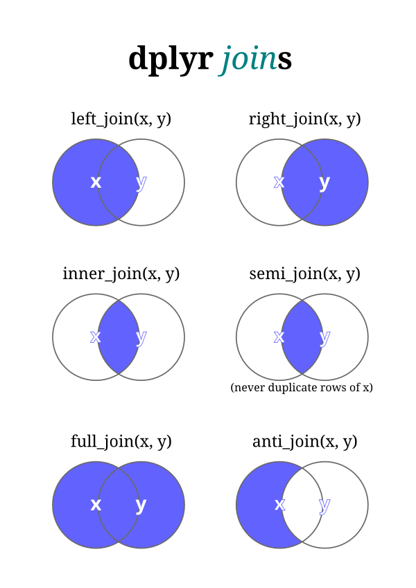

fuente: http://rstudio-pubs-static.s3.amazonaws.com/227171_618ebdce0b9d44f3af65700e833593db.html

### left_join

Veamos un ejemplo de la función **left_join** (una de las más utilizadas en la práctica).  
Para ello utilizaremos el Dataframe *Aglom* con los códigos y los nombres de los aglomerados EPH

```r
Aglom
```

|  | AGLOMERADO | Nom_Aglo |
| --- | --- | --- |
| 1 | 32 | Ciudad de Bs As |
| 2 | 33 | Partidos del GBA |
| 3 | 10 | Gran Mendoza |
| 4 | 27 | Gran San Juan |
| 5 | 26 | San Luis - El Chorrillo |
| 6 | 12 | Corrientes |
| 7 | 15 | Formosa |
| 8 | 8 | Gran Resistencia |
| 9 | 7 | Posadas |
| 10 | 22 | Gran Catamarca |

[output cut: 22 more lines]

```r
Datos_join <- Datos %>%
  left_join(.,Aglom, by = "AGLOMERADO")

Datos_join
```

| AGLOMERADO | MAS_500 | CH04 | EDAD | P47T | PONDERA | PONDII | Edad_cuadrado | Edad_cubo | Grupos_Etarios | edad.corregida | Nom_Aglo |
| --- | --- | --- | --- | --- | --- | --- | --- | --- | --- | --- | --- |
| 2 | S | 1 | -1 | 0 | 779 | 779 | 1 | -1 | Menores | 0 | Gran La Plata |
| 2 | S | 1 | -1 | 0 | 830 | 830 | 1 | -1 | Menores | 0 | Gran La Plata |
| 2 | S | 1 | -1 | 0 | 528 | 528 | 1 | -1 | Menores | 0 | Gran La Plata |
| 2 | S | 1 | -1 | 0 | 783 | 783 | 1 | -1 | Menores | 0 | Gran La Plata |
| 2 | S | 1 | -1 | 0 | 531 | 531 | 1 | -1 | Menores | 0 | Gran La Plata |
| 2 | S | 1 | -1 | 0 | 513 | 513 | 1 | -1 | Menores | 0 | Gran La Plata |
| 2 | S | 1 | -1 | 0 | 794 | 794 | 1 | -1 | Menores | 0 | Gran La Plata |
| 2 | S | 1 | -1 | 0 | 1137 | 1137 | 1 | -1 | Menores | 0 | Gran La Plata |
| 3 | N | 1 | -1 | 0 | 209 | 209 | 1 | -1 | Menores | 0 | Bahía Blanca - Cerri |
| 3 | N | 1 | -1 | 0 | 220 | 220 | 1 | -1 | Menores | 0 | Bahía Blanca - Cerri |

[output cut: 990 more lines]

```r
Poblacion_Aglomerados <- Datos_join %>%
  group_by(Nom_Aglo) %>%
  summarise(Menores = sum(PONDERA[Grupos_Etarios=="Menores"]),
            Adultos = sum(PONDERA[Grupos_Etarios=="Adultos"]),
            Adultos_Mayores = sum(PONDERA[Grupos_Etarios=="Adultos Mayores"]))

Poblacion_Aglomerados
```

| Nom_Aglo | Menores | Adultos | Adultos_Mayores |
| --- | --- | --- | --- |
| Bahía Blanca - Cerri | 83725 | 188922 | 35808 |
| Cdro. Rivadavia - R.Tilly | 63363 | 135458 | 21536 |
| Ciudad de Bs As | 553792 | 1856065 | 517032 |
| Concordia | 35786 | 64167 | 9127 |
| Corrientes | 93524 | 244599 | 31550 |
| Formosa | 72079 | 150662 | 20723 |
| Gran Catamarca | 64351 | 132955 | 17244 |
| Gran Córdoba | 388929 | 970824 | 170747 |
| Gran La Plata | 208006 | 546227 | 106152 |
| Gran Mendoza | 258069 | 551352 | 128479 |

[output cut: 22 more lines]

```r
NA
```

## Tidyr

El paquete tidyr esta pensado para facilitar el emprolijamiento de los datos. Veremos las funciones *pivot_longer* y *pivot_wider* que nos permitirán pivotear la base según como queramos ordenar los datos para trabajarlos posteriormente o bien para presentarlos como tabla de resultados.

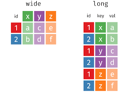

fuente: https://bookdown.org/Maxine/r4ds/pivoting.html

### pivot_longer

Nos permite pivotear los datos en columnas hacia una única variable. El *“longer”* refiere a que ahora nuestro dataframe va a tener más filas (y menos columnas)

```r
pob.aglo.long <- Poblacion_Aglomerados %>%
  pivot_longer(cols = 2:4,names_to = "Grupo_Etario",values_to = "Poblacion")

pob.aglo.long
```

| Nom_Aglo | Grupo_Etario | Poblacion |
| --- | --- | --- |
| Bahía Blanca - Cerri | Menores | 83725 |
| Bahía Blanca - Cerri | Adultos | 188922 |
| Bahía Blanca - Cerri | Adultos_Mayores | 35808 |
| Cdro. Rivadavia - R.Tilly | Menores | 63363 |
| Cdro. Rivadavia - R.Tilly | Adultos | 135458 |
| Cdro. Rivadavia - R.Tilly | Adultos_Mayores | 21536 |
| Ciudad de Bs As | Menores | 553792 |
| Ciudad de Bs As | Adultos | 1856065 |
| Ciudad de Bs As | Adultos_Mayores | 517032 |
| Concordia | Menores | 35786 |

[output cut: 86 more lines]

### pivot_wider

Es el opuesto de **pivot_longer**. Nos permite pivotear los datos de una variable para obtener múltiples columnas en función de alguna variable categórica que clasifique a la anterior. El “wider” refiere a que ahora nuestro dataframe va a tener menos filas (y más columnas, en función de la cantidad de categorías de la variable que use para pivotear)

```r
pob.aglo.long %>%
  pivot_wider(names_from = "Grupo_Etario",values_from = "Poblacion")
```

| Nom_Aglo | Menores | Adultos | Adultos_Mayores |
| --- | --- | --- | --- |
| Bahía Blanca - Cerri | 83725 | 188922 | 35808 |
| Cdro. Rivadavia - R.Tilly | 63363 | 135458 | 21536 |
| Ciudad de Bs As | 553792 | 1856065 | 517032 |
| Concordia | 35786 | 64167 | 9127 |
| Corrientes | 93524 | 244599 | 31550 |
| Formosa | 72079 | 150662 | 20723 |
| Gran Catamarca | 64351 | 132955 | 17244 |
| Gran Córdoba | 388929 | 970824 | 170747 |
| Gran La Plata | 208006 | 546227 | 106152 |
| Gran Mendoza | 258069 | 551352 | 128479 |

[output cut: 22 more lines]

```r
NA
```

# Tasas del Mercado de Trabajo

Luego de abordar las principales funciones necesarias para operar sobre las bases de datos, trabajaremos a continuación con otras variables de la base del 1er Trimestre de 2017 de la EPH. El ejercicio principal consistirá en calcular la **tasa de empleo**, definida como:

- Tasa de empleo: $\frac{Ocupados}{Población}$

En la carpeta de *FUENTES* del curso, se encuentra el archivo *“EPH_Registro”* que contiene las codificación de cada una de las variables de la base, y el archivo *“EPH_Concpetos_Actividad”* que contiene las definiciones de los Estados ocupacionales a partir de los cuales se construyen las tasas básicas.

## Tasa de Empleo agregada

Creamos una tabla con los niveles de:

- Población
- Ocupados

```r
Poblacion_ocupados <- Individual_t117 %>%
  summarise(Poblacion         = sum(PONDERA),
            Ocupados          = sum(PONDERA[ESTADO == 1]))

Poblacion_ocupados
```

| Poblacion | Ocupados |
| --- | --- |
| 27416497 | 11328384 |

- Población: Si contaramos cuantos registros tiene la base, simplemente tendríamos el numero de individuos muestral de la EPH, por ende debemos **sumar los valores de la variable PONDERA**, para contemplar a cuantas personas representa cada individuo encuestado.
- Ocupados: En este caso, debemos agregar un **filtro** al procedimiento anterior, ya que unicamente queremos sumar los ponderadores de aquellas personas que se encuentran ocupadas. (La lógica seria: “Suma los valores de la columna PONDERA, solo para aquellos registros donde el ESTADO == 1”)

La función `summarise()` nos permite crear multiples variables de resumen al mismo tiempo, simplemente separando con una `,` cada uno de ellas. A su vez, se pueden crear variables, a partir de las variables creadas por la propia función. De esta forma, podemos, directamente calcular la **tasa de empleo** a partir del total poblacional y de ocupados.

```r
Empleo <- Individual_t117 %>%
  summarise(Poblacion         = sum(PONDERA),
            Ocupados          = sum(PONDERA[ESTADO == 1]),
            Tasa_Empleo    = Ocupados/Poblacion)

Empleo
```

| Poblacion | Ocupados | Tasa_Empleo |
| --- | --- | --- |
| 27416497 | 11328384 | 0.4131959 |

En caso de querer expresar los resultados como porcentajes, podemos utilizar la función **percent** del paquete *scales*. Para ello debemos utilizar **mutate** para transformar la variable `Tasa_Empleo`

Nótese que en este caso, para poder añadir el %, la función transforma a la variable en un Character, por ende debe tenerse en cuenta que se pierde la información del numero completo. Esto es simplemente una herramienta para visualizar la información final en terminos de %, no utilizarla si se va a seguir operando con dicho valor.

```r
Empleo %>%
  mutate(Tasa_Empleo_Porc = scales::percent(Tasa_Empleo))
```

| Poblacion | Ocupados | Tasa_Empleo | Tasa_Empleo_Porc |
| --- | --- | --- | --- |
| 27416497 | 11328384 | 0.4131959 | 41% |

## Tasa de Empleo por aglomerado

Replicando el procedimiento anterior, pero añadiendo previamente un `group_by()`, podemos realizar la misma estimación, pero desagregada por alguna variable de interés (por ejemplo, por aglomerado)

```r
Empleo_aglo <- Individual_t117 %>%
  group_by(AGLOMERADO)%>%
  summarise(Poblacion         = sum(PONDERA),
            Ocupados          = sum(PONDERA[ESTADO == 1]),
            Tasa_Empleo    = Ocupados/Poblacion)
```

# Exportar resultados a Excel

La función **write.xlsx** de la libreria [openxlsx](https://ycphs.github.io/openxlsx/) nos permite exportar un dataframe a un archivo de Excel. Hay una infinidad de formas para hacer la exportación, agregando títulos a los cuadros, múltiples dataframes en una misma solapa del excel, o creando múltiples solapas en el excel. Todas estas variantes, con ejemplos, se pueden consultar [acá](https://ycphs.github.io/openxlsx/articles/Introduction.html).

La forma más simple, sólo requiere indicar el dataframe a exportar, y la ruta completa, con extensión del archivo incluido

```r
dir.create("Resultados")
openxlsx::write.xlsx(x = Empleo,file =  "Resultados/miexportacion.xlsx")
```

Si queremos exportar más de un objeto, cada uno a una pestaña distinta, lo que tenemos que pasar en el parámetro `x` es una lista de objetos.

```r
dir.create("Resultados")
openxlsx::write.xlsx(
  x = list(Empleo,Empleo_aglo),
  file =  "Resultados/miexportacion_2.xlsx")
```